# Dey Sarkar_Arnab_HW_06

## Problem 03

Read in the `hw05_prob_03.csv` CSV file and assign it to the `df03` object.

Visually explore the `df03` object following **ALL** required actions listed previously.

You must add more code cells and markdown cells to complete this problem.

#### 03) - SOLUTION

```python
###
df03=pd.read_csv("hw05_prob_03.csv")
```

```python
df03.info()
```

```
<class 'pandas.core.frame.DataFrame'>
RangeIndex: 1407 entries, 0 to 1406
Data columns (total 3 columns):
 #   Column  Non-Null Count  Dtype
---  ------  --------------  -----
 0   obs_id  1407 non-null   int64
 1   key     1407 non-null   object
 2   value   1379 non-null   float64
dtypes: float64(1), int64(1), object(1)
memory usage: 33.1+ KB
```

```python
df03.dtypes
```

```
obs_id      int64
key        object
value     float64
dtype: object
```

```python
df03.isna().sum()
```

```
obs_id     0
key        0
value     28
dtype: int64
```

```python
df03.nunique()
```

```
obs_id     201
key          7
value     1379
dtype: int64
```

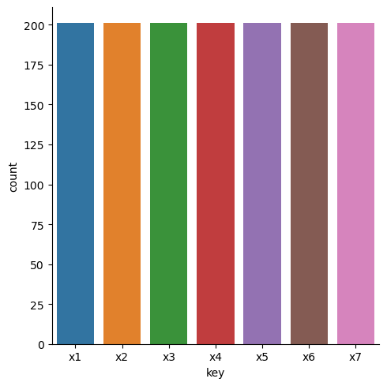

```python
# * Create BAR CHARTS to visually show the counts
# for the number of rows per unique value for NON-NUMERIC columns
#  * You may use Pandas or Seaborn to create the bar charts

sns.catplot(data=df03, x='key', kind='count')
```

- **IMPORTANT:** After creating BAR CHARTS and HISTOGRAMS answer the following:
  - Do the categories of the NON-NUMERIC columns have similar counts?
  - Do the histograms of the NUMERIC columns look roughly like bell curves?

Yes, they have similar counts.

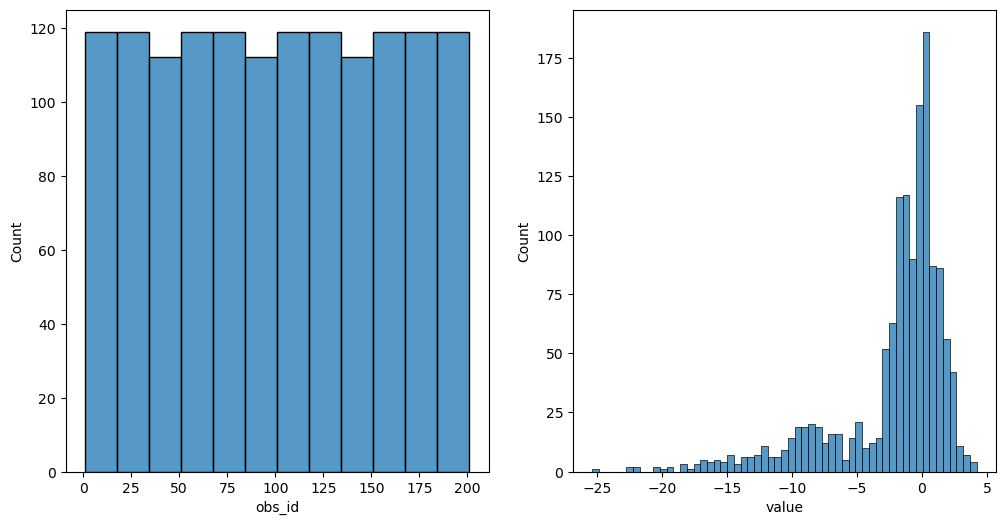

```python
# * Create HISTOGRAMS to visually show the DISTRIBUTION of NUMERIC columns
#     * You may use Pandas or Seaborn to create the histogram
# * **IMPORTANT:** You **MUST** visually explore the counts of NUMERIC columns

fig, axs =plt.subplots(1,2, figsize=(12,6))

sns.histplot(data=df03, x='obs_id', ax=axs[0])
sns.histplot(data=df03, x='value', ax=axs[1])
```

No, both of them doesn't look like a bell curve. Obs_id looks like uniformly spreaded and value is left skewed.

For each of the 3 assigned data sets you must create plots/figures/charts to explore **combinations** between 2 NON-NUMERIC columns. You must therefore perform the following tasks:

- Create DODGED bar charts to visually show the COUNTS for COMBINATIONS between 2 NON-NUMERIC columns
  - You **MUST** create the DODGED bar chart using Seaborn
- Create HEAT MAPS to visually show the COUNTS for COMBINATIONS between 2 NON-NUMERIC columns
  - You **MUST** create the HEAT MAP using Seaborn
  - The HEAT MAP **MUST** be annotated with count displayed as TEXT
- **IMPORTANT:** You **MUST** treat NUMERIC columns that have less than 20 unique values as if they are NON-NUMERIC columns
- **IMPORTANT:** After creating the DODGED bar charts and HEAT MAPS answer the following:
  - Are there combinations between the 2 variables NOT present in the data?
  - Which plot type was it easier to identify combinations that were NOT present?

### This entire portion is not applicable here as we just have one categorical column.

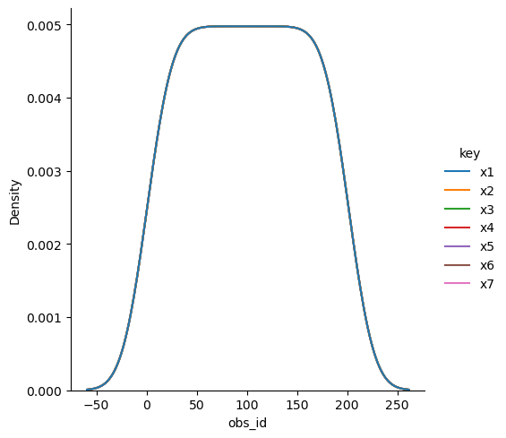

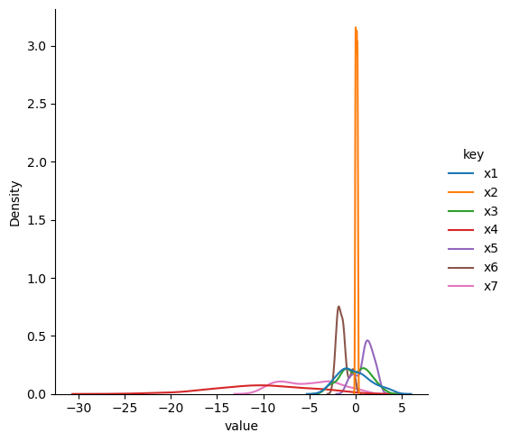

```python
# For each of the 3 assigned data sets you must create plots/figures/charts
# to explore **relationships** between CATEGORICAL and CONTINUOUS variables.
# You must therefore explore the relationship between 1 NON-NUMERIC column and 1 NUMERIC column.
# You must perform the following tasks:

# * Create CONDITIONAL KDE plots to show the conditional distribution of the NUMERIC column
# CONDITIONED ON (or GROUPED BY) the NON-NUMERIC column
#     * You **MUST** create the CONDITIONAL KDE plot using Seaborn with the
#       NON-NUMERIC column associated with the KDE COLOR
#     * You **MUST** remove the SAMPLE SIZE issue with the CONDITIONAL KDE plot

sns.displot(data=df03, x='obs_id', hue='key', kind='kde', common_norm=False)
sns.displot(data=df03, x='value', hue='key', kind='kde', common_norm=False)

plt.show()
```

- **IMPORTANT:** After creating the figures you must answer the following:
  - Does the distributional SHAPE of a NUMERIC column appear to be different across the CATEGORIES of the NON-NUMERIC column?

No for obs_id, all are almost same.

For value, they are diverse. E.g., x2 has a sharp pick at 0 and the values are condensed around 0 with low variance then x6 has a pick around -2 and x5 has a pick around 1.5.

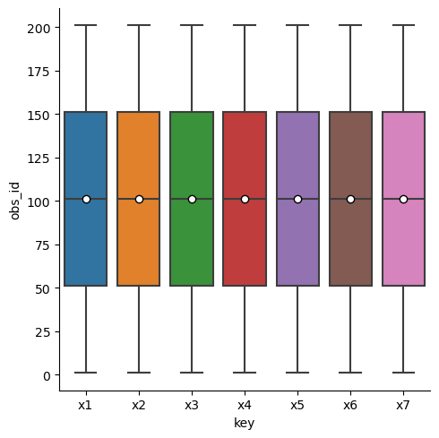

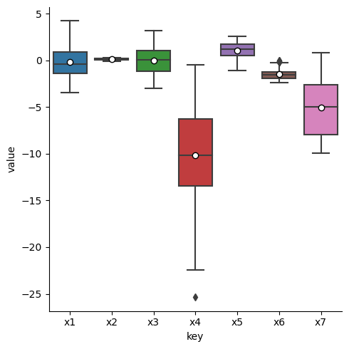

```python
# * Create BOXPLOTS to show if the SUMMARY STATISTICS of the NUMERIC column
#   CHANGE across the CATEGORIES of the NON-NUMERIC column
#     * You **MUST** create the BOXPLOT using Seaborn

sns.catplot(data=df03, x='key', y='obs_id', kind='box', showmeans=True,\
    meanprops={'marker':'o', 'markerfacecolor': 'white', 'markeredgecolor': 'black'} )
sns.catplot(data=df03, x='key', y='value', kind='box', showmeans=True,\
    meanprops={'marker':'o', 'markerfacecolor': 'white', 'markeredgecolor': 'black'} )

plt.show()
```

- Does the MEDIAN of the NUMERIC column appear to be different across the CATEGORIES

- Does the VARIATION of the NUMERIC column appear to be different across the CATEGORIES

In obs_id the box plots are same across key.

Median and variation of numeric column of x4 and x7 stand out from the rest. Even median and variation of numeric column are different b/w x4 and x7. The others are close enough in medians but differe in variation of num col.

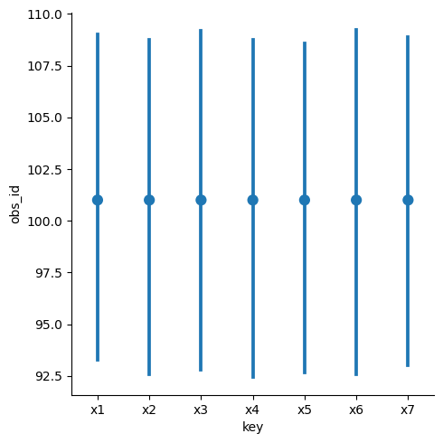

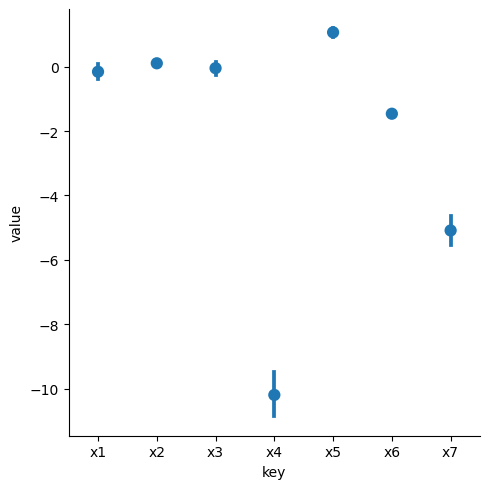

```python
# * Create POINT PLOTS to show if the CONDITIONAL MEAN of the NUMERIC columns
#   CHANGE across the CATEGORIES of the NON-NUMERIC column
#     * You **MUST** create the POINT PLOT using Seaborn
# * **IMPORTANT:** You **MUST** treat NUMERIC columns that have less than 20 unique
#     values as if they are NON-NUMERIC columns

sns.catplot(data=df03, x='key', y='obs_id', kind='point', join=False)
sns.catplot(data=df03, x='key', y='value', kind='point', join=False)

plt.show()
```

- Are you confident that the MEAN of the NUMERIC column CHANGES across the CATEGORIES

Not at all 'confident' in obs_id but coonfident in 'value' for {x4,x5,x6 and x7} vs {x1,x2,x3} to name a few.

We are also 95% sure that mean of x4 is different than the others.

We are also 95% sure that mean of x5 is different than the others.

We are also 95% sure that mean of x6 is different than the others.

We are also 95% sure that mean of x7 is different than the others.

Again among x1,x2,x3 we are not confident.

## Problem 04

You must download the data associated with one of the Final Projects from the Canvas site. Save the file(s) in the same directory as this Jupyter notebook.

Read in the data associated with one of the Final Projects. You must start to visually explore the variables in the Project data. However, you do NOT need to explore ALL variables in this assignment.

You **MUST** visually explore the **marginal** behavior of at least 6 variables. You must use the plot type appropriate for the data type and number of unique values for each variable.

#### 04) - SOLUTION

```python
###
df04=pd.read_csv("training_data.csv")
```

```python
%%capture
df04.info()
```

```python
df04.dtypes
```

```
X01    float64
X02    float64
X03    float64
X04    float64
X05    float64
        ...
V26    float64
V27    float64
V28    float64
V29    float64
Y        int64
Length: 64, dtype: object
```

```python
df04.dtypes.value_counts()
```

```
float64    63
int64       1
dtype: int64
```

```python
df04.isna().sum().value_counts()
```

```
0    64
dtype: int64
```

```python
df04.nunique()
```

```
X01    223
X02    223
X03    223
X04    223
X05    223
      ...
V26    223
V27    223
V28    223
V29    223
Y        2
Length: 64, dtype: int64
```

```python
df04.nunique().value_counts()
```

```
223    63
2       1
dtype: int64
```

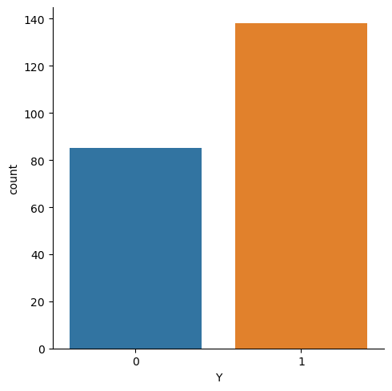

```python
# * Create BAR CHARTS to visually show the counts for the number of
# rows per unique value for NON-NUMERIC columns
#     * You may use Pandas or Seaborn to create the bar charts

sns.catplot(data=df04, x='Y', kind='count')
```

- **IMPORTANT:** After creating BAR CHARTS and HISTOGRAMS answer the following:
  - Do the categories of the NON-NUMERIC columns have similar counts?
  - Do the histograms of the NUMERIC columns look roughly like bell curves?

No, the category 1 has larger count here.

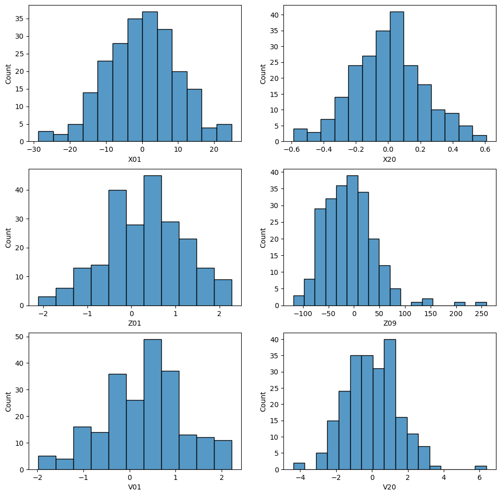

```python
# * Create HISTOGRAMS to visually show the DISTRIBUTION of NUMERIC columns
#     * You may use Pandas or Seaborn to create the histogram
# * **IMPORTANT:** You **MUST** visually explore the counts of NUMERIC
# columns that have less than 20 unique values as if they are NON-NUMERIC columns

fig, axs= plt.subplots(3,2,figsize=(12,12))

sns.histplot(data=df04, x='X01', ax=axs[0,0])
sns.histplot(data=df04, x='X20', ax=axs[0,1])
sns.histplot(data=df04, x='Z01', ax=axs[1,0])
sns.histplot(data=df04, x='Z09', ax=axs[1,1])
sns.histplot(data=df04, x='V01', ax=axs[2,0])
sns.histplot(data=df04, x='V20', ax=axs[2,1])

plt.show()
```

Everything except Z09 looks similar to bell shaped. I am ignoring some rare peaks like to the left of 0 in Z01,V01 etc. Overall looks like normal except Z09 which is right skewed.